# Tutorial 01 Hi-C-Analysis

In this file is shown a basic introduction on how to use the Hi-C-Analysis package to performa a spectral analysis and visualize the results.

In this script, only to shows how the main functions work, it will be used a square and symmetric random matrix created with numpy and a fake dataframe containing the start and stop indices of the chromosomes Hi-C matrices:

```python
import numpy as np
import pandas as pd

np.random.seed(42)
adjacency = 500 * np.random.random((300, 300))
adjacency += adjacency.T

data = {'chr':['chr1', 'chr2', 'chr3', 'chr4'], 'start':[1, 100, 190, 270], 'end':[99, 189, 269, 299 ]}

metadata = pd.DataFrame(data)
metadata
```

|  | chr | start | end |
| --- | --- | --- | --- |
| 0 | chr1 | 1 | 99 |
| 1 | chr2 | 100 | 189 |
| 2 | chr3 | 190 | 269 |
| 3 | chr4 | 270 | 299 |

Now that the adjacecy matrix is created let's import the other packages needed for the process.

```python
from pathlib import Path
import hicanalysis.preprocessing as pre
import hicanalysis.visualizegraph as vg
from scipy.stats import pearsonr
```

To normalize the adjacency matrix with the Observed Over Expected normalization:

```python
normalized_adj = pre.ooe_normalization(adjacency)
```

In order to extract the blocks of the chromsomes from the diagonal of the normalized adjacency it is enough to apply the function get_chromosome_list and to provide the list to extract_diagonal_blocks:

```python
list = pre.get_chromosome_list(metadata)

blocks = pre.extract_diagonal_blocks(normalized_adj, list)
```

in order to visualize them it's possible to use the visualizegraph module:

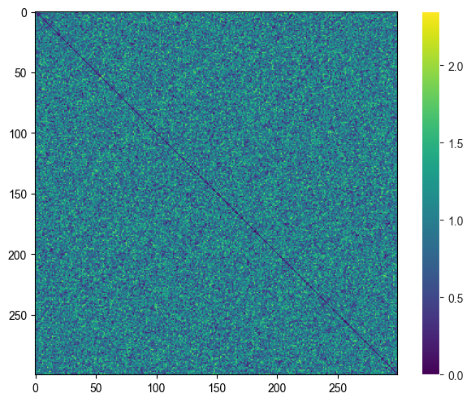

```python
vg.plot_matrix(normalized_adj)
```

Then it is possible to use the numpy library to find the eigenvalues and eigenvectors of the matrix, and order them from the greater to the smaller eigenvalues

```python
eigenvalues, eigenvectors = np.linalg.eig(normalized_adj)

idx = eigenvalues.argsort()[::-1]
eigenvalues = eigenvalues[idx]
eigenvectors = eigenvectors[:,idx]
```

The obtained results can be passed to the build_projection function, that, from the eigenvectors, create the corresponding projectors:

```python
projectors = pre.build_projectors(eigenvectors, 4)
```

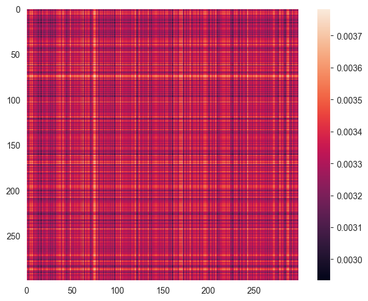

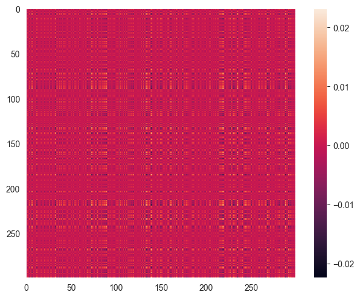

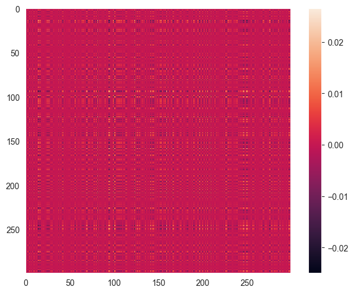

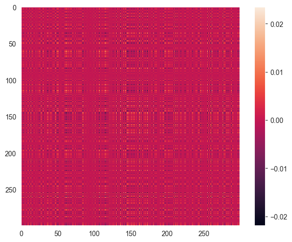

```python
for projector in projectors:
    vg.plot_matrix(projector)
```

Finally it is possible to reconstruct the original matrix by adding together the projectors, that should be similar to the original one (in this case we used a random matrix so the behaviour should be different when using real data):

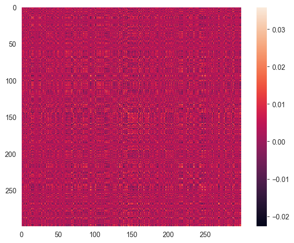

```python
reconstructed_matrix = pre.reconstruct_matrix(projectors, 4)
vg.plot_matrix(reconstructed_matrix)
```

It is also possible to compare the reconstructed and original matrix with a scatter plot and computing the pearson coefficient:

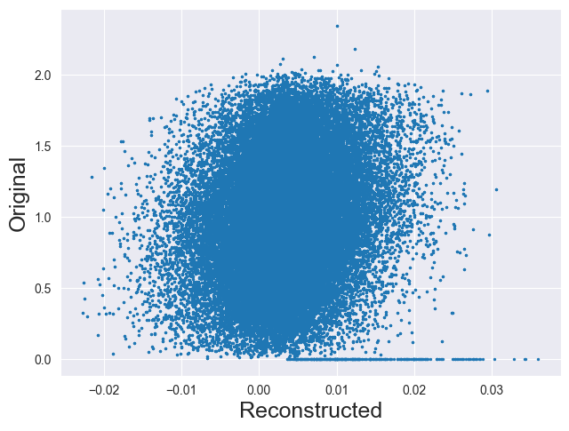

```
Pearson correlation coeffient: 0.177039794231876
```

```python
vg.scatter_plot(reconstructed_matrix,
                    normalized_adj,
                    'Reconstructed',
                    'Original',
                    )
corr, _ = pearsonr(reconstructed_matrix.flatten(), normalized_adj.flatten())
print(f'Pearson correlation coeffient: {corr}')
```